# 🚗 **Car Trust API Logs Analysis Report**

### **Data Window**: May – July 2025

### **Prepared by**: Abid Aziz Khan

### **Date**: 22-07-2025

## **Key Deliverables**

- Usage trends by endpoint, vendor, and time
- Pricing insights by model, trim, year
- Performance bottlenecks & VIN repeat patterns
- Visualized insights for business stakeholders

## 1. Project Objective

Analyze vehicle pricing API call logs to uncover patterns in system usage, vendor behavior, evaluated pricing, and latency. The insights guide business decisions for optimization, vendor management, and product scaling.

## 2. Dataset Overview

- **Source**: MySQL dump of `product_api_logs`
- **Records Analyzed**: 20,000
- **Time Range**: May to July 2025 (randomized for simulation)
- **Key Fields**:
  - `endpoint`, `vendor_id`, `vin`, `evaluated_price`
  - `manufacturer`, `model`, `year`, `trim`
  - `processing_time_ms`, `created_at`

## 3. Data Preparation

- Parsed JSON fields from request/response
- Converted prices and year to numeric
- Extracted month from `created_at` for time series
- Simulated timestamps across May–July 2025
- Removed nulls, handled outliers
- Focused on a 20K-row sample due to size constraints

## 4. Key Insights

### API Usage & Vendor Behavior

- **Endpoints Used**:
  - `usedCarPriceWithSpecs`: 14,332 requests
  - `usedCarPriceWithSpecsSafetyReliability`: 5,164 requests
- **Top Vendors by Volume**:
  - Vendor 21 → 8,945 requests
  - Vendor 31 → 5,751
  - Vendor 24 → 5,304 (uses safety endpoint only)
- **Most Cars Evaluated (Unique VINs)**:
  - Vendor 31 → 3,141 cars
  - Vendor 21 → 3,023

## 5. Recommendations

- Optimize logic for older truck models (Actros) with slow response times
- Use VIN repeats (~3,000 duplicates) for caching or performance boosts
- Create premium plans for vendors using safety-enhanced endpoint
- Build vendor dashboards (Vendor 21 & 24 use APIs differently)
- Consider dynamic pricing tiers for high-value vehicle segments

## 7. Appendix

- Code for all groupings and visualizations
- Monthly breakdowns and VIN-based filters
- Exportable charts ready for PDF/HTML use

```python
!pip install SQLAlchemy pymysql
from sqlalchemy import create_engine

engine = create_engine("mysql+pymysql://root:abid123@localhost/product_logs_db")

df = pd.read_sql("SELECT * FROM product_api_logs LIMIT 20000", engine)
df.head(200)
```

|  | id | vendor_id | endpoint | request_data | response_data | created_at | updated_at | response_type | sync_status | processing_time_ms | manufacturer | model | year | trim | lower_limit | upper_limit | evaluated_price | vin |
| --- | --- | --- | --- | --- | --- | --- | --- | --- | --- | --- | --- | --- | --- | --- | --- | --- | --- | --- |
| 0 | 49347394 | 21 | usedCarPriceWithSpecs | {"vin": "MAJTK1BA9GAA72380"} | {"code": "ct-200", "message": "ok", "success":... | 2025-07-14 08:00:00 | 2025-06-18 20:05:44 | 1 | 0 | 12.68 | Ford | EcoSport | 2016 | Ambient | 24899 | 30464 | 29292 | MAJTK1BA9GAA72380 |
| 1 | 49347395 | 24 | usedCarPriceWithSpecsSafetyReliability | {"vin": "JTDBZ42E089000909"} | {"code": "ct-200", "message": "ok", "success":... | 2025-07-14 08:00:00 | 2025-06-18 20:05:45 | 1 | 0 | 40.31 | Toyota | Corolla | 2008 | 1.6L XLi | 24288 | 29717 | 28574 | JTDBZ42E089000909 |
| 2 | 49347396 | 31 | usedCarPriceWithSpecs | {"vin": "1GNSC7EC8GR177730"} | {"code": "ct-200", "message": "ok", "success":... | 2025-07-14 08:00:00 | 2025-06-18 20:05:47 | 1 | 0 | 24.56 | Chevrolet | Tahoe | 2016 | LTZ | 65174 | 79743 | 76676 | 1GNSC7EC8GR177730 |
| 3 | 49347397 | 24 | usedCarPriceWithSpecsSafetyReliability | {"vin": "LVSFMBFC9RSC26668"} | {"code": "ct-200", "message": "ok", "success":... | 2025-07-14 08:00:00 | 2025-06-18 20:05:47 | 1 | 0 | 18.13 | Ford | Taurus | 2024 | 2.0L EcoBoost Ambient | 85061 | 104074 | 100072 | LVSFMBFC9RSC26668 |
| 4 | 49347398 | 21 | usedCarPriceWithSpecs | {"vin": "MRJRS384XSP050230"} | {"code": "ct-0006", "message": "Base Price not... | 2025-07-14 08:00:00 | 2025-06-18 20:05:48 | 4 | 0 | 14.02 | NULL | NULL | NULL | NULL | NULL | NULL | NULL | MRJRS384XSP050230 |
| ... | ... | ... | ... | ... | ... | ... | ... | ... | ... | ... | ... | ... | ... | ... | ... | ... | ... | ... |
| 195 | 49347589 | 31 | usedCarPriceWithSpecs | {"vin": "JM7KFAWLXR0109874"} | {"code": "ct-200", "message": "ok", "success":... | 2025-07-14 08:00:00 | 2025-06-18 20:06:28 | 1 | 0 | 19.86 | Mazda | CX-5 | 2024 | 2.5L Full Option AWD | 98265 | 120230 | 115606 | JM7KFAWLXR0109874 |
| 196 | 49347590 | 21 | usedCarPriceWithSpecs | {"vin": "KMHJT81C4BU249427"} | {"code": "ct-200", "message": "ok", "success":... | 2025-07-14 08:00:00 | 2025-06-18 20:06:29 | 1 | 0 | 12.25 | Hyundai | Tucson | 2011 | 2.0L FWD | 18294 | 22383 | 21522 | KMHJT81C4BU249427 |
| 197 | 49347591 | 21 | usedCarPriceWithSpecs | {"vin": "KMHJT81C4BU249427"} | {"code": "ct-200", "message": "ok", "success":... | 2025-07-14 08:00:00 | 2025-06-18 20:06:29 | 1 | 0 | 10.36 | Hyundai | Tucson | 2011 | 2.0L FWD | 18294 | 22383 | 21522 | KMHJT81C4BU249427 |
| 198 | 49347592 | 24 | usedCarPriceWithSpecsSafetyReliability | {"vin": "KMHJT81C4BU249427"} | {"code": "ct-200", "message": "ok", "success":... | 2025-07-14 08:00:00 | 2025-06-18 20:06:29 | 1 | 0 | 12.69 | Hyundai | Tucson | 2011 | 2.0L FWD | 18294 | 22383 | 21522 | KMHJT81C4BU249427 |
| 199 | 49347593 | 21 | usedCarPriceWithSpecs | {"vin": "RKLBB9HE8J5216404"} | {"code": "ct-200", "message": "ok", "success":... | 2025-07-14 08:00:00 | 2025-06-18 20:06:29 | 1 | 0 | 51.99 | Toyota | Corolla | 2018 | 1.6L XLI | 33127 | 40532 | 38973 | RKLBB9HE8J5216404 |

200 rows × 18 columns

```python
df_count = pd.read_sql("SELECT COUNT(*) AS total FROM product_api_logs", engine)
df_count
```

|  | total |
| --- | --- |
| 0 | 1000063 |

## Check For Missing Values

```python
df.isnull().sum().sort_values(ascending=False)
```

```
id                    0
vendor_id             0
evaluated_price       0
upper_limit           0
lower_limit           0
trim                  0
year                  0
model                 0
manufacturer          0
processing_time_ms    0
sync_status           0
response_type         0
updated_at            0
created_at            0
response_data         0
request_data          0
endpoint              0
vin                   0
dtype: int64
```

## Check Data Types and Column Structure

```python
df.info()
```

```
<class 'pandas.core.frame.DataFrame'>
RangeIndex: 20000 entries, 0 to 19999
Data columns (total 18 columns):
 #   Column              Non-Null Count  Dtype
---  ------              --------------  -----
 0   id                  20000 non-null  int64
 1   vendor_id           20000 non-null  object
 2   endpoint            20000 non-null  object
 3   request_data        20000 non-null  object
 4   response_data       20000 non-null  object
 5   created_at          20000 non-null  datetime64[ns]
 6   updated_at          20000 non-null  datetime64[ns]
 7   response_type       20000 non-null  int64
 8   sync_status         20000 non-null  int64
 9   processing_time_ms  20000 non-null  float64
 10  manufacturer        20000 non-null  object
 11  model               20000 non-null  object
 12  year                20000 non-null  object
 13  trim                20000 non-null  object
 14  lower_limit         20000 non-null  object
 15  upper_limit         20000 non-null  object
 16  evaluated_price     20000 non-null  object
 17  vin                 20000 non-null  object
dtypes: datetime64[ns](2), float64(1), int64(3), object(12)
memory usage: 2.7+ MB
```

```python
cols_to_fix = ['lower_limit', 'upper_limit', 'evaluated_price']

for col in cols_to_fix:
    df[col] = pd.to_numeric(df[col], errors='coerce')
```

```python
df[cols_to_fix].isnull().sum()
```

```
lower_limit        504
upper_limit        504
evaluated_price    504
dtype: int64
```

```python
df = df.dropna(subset=['lower_limit', 'upper_limit', 'evaluated_price'])
print("Remaining rows:", len(df))
```

```
Remaining rows: 19496
```

## Total Number of Unique Endpoints.

```python
unique_endpoints = df['endpoint'].nunique()
print("Total unique endpoints:", unique_endpoints)
```

```
Total unique endpoints: 2
```

```python
df['endpoint'].unique()
```

```
array(['usedCarPriceWithSpecs', 'usedCarPriceWithSpecsSafetyReliability'],
      dtype=object)
```

## usage count for each endpoint:

```python
df['endpoint'].value_counts()
```

```
endpoint
usedCarPriceWithSpecs                     14332
usedCarPriceWithSpecsSafetyReliability     5164
Name: count, dtype: int64
```

### Insight #1: Endpoint Usage Breakdown

Out of the 20,000 API log records analyzed:

- **usedCarPriceWithSpecs**: 14,332 requests (≈ 73%)
- **usedCarPriceWithSpecsSafetyReliability**: 5,164 requests (≈ 27%)

This clearly indicates that `usedCarPriceWithSpecs` is the **primary endpoint**, likely serving the core pricing function.  
In contrast, the other endpoint appears more specialized or newer and may warrant further performance and reliability evaluation.

```python
import pandas as pd
import numpy as np

df_simulated = df.copy()

# Generate random months: May, June, July 2025
np.random.seed(42)
df_simulated['created_at'] = pd.to_datetime(
    np.random.choice(
        pd.date_range("2025-05-01", "2025-07-31", freq='D'),
        size=len(df_simulated)
    )
)

df_simulated['month'] = df_simulated['created_at'].dt.to_period('M')
```

## Compare average response time:

```python
df.groupby('endpoint')['processing_time_ms'].mean()
```

```
endpoint
usedCarPriceWithSpecs                     28.640693
usedCarPriceWithSpecsSafetyReliability    27.032883
Name: processing_time_ms, dtype: float64
```

### ⏱️ Insight #2: Processing Time by Endpoint

Although both endpoints perform quickly, the more heavily used endpoint (`usedCarPriceWithSpecs`) is slightly slower.  
This may indicate a need to monitor and optimize for scalability as traffic continues to increase.

## Compare sync success/failure rates:

```python
df.groupby('endpoint')['sync_status'].value_counts(normalize=True) * 100
```

```
endpoint                                sync_status
usedCarPriceWithSpecs                   0              100.0
usedCarPriceWithSpecsSafetyReliability  0              100.0
Name: proportion, dtype: float64
```

### Insight #3: Sync Status — 100% Success Rate

Both API endpoints (`usedCarPriceWithSpecs` and `usedCarPriceWithSpecsSafetyReliability`) show a **100% sync success rate** in this sample:

- `sync_status = 0` in all 20,000 records analyzed
- No failures, timeouts, or retries recorded

## Compare average evaluated price

```python
# Convert evaluated_price to numeric, force errors to NaN
df_simulated['evaluated_price'] = pd.to_numeric(df_simulated['evaluated_price'], errors='coerce')

# Now you can safely group and calculate the mean
result = df_simulated.groupby('endpoint')['evaluated_price'].mean()
print(result)
```

```
endpoint
usedCarPriceWithSpecs                     52475.136617
usedCarPriceWithSpecsSafetyReliability    54662.268397
Name: evaluated_price, dtype: float64
```

```python
df_simulated.groupby('endpoint')['evaluated_price'].mean()
```

```
endpoint
usedCarPriceWithSpecs                     52475.136617
usedCarPriceWithSpecsSafetyReliability    54662.268397
Name: evaluated_price, dtype: float64
```

| Endpoint Name | Avg. Evaluated Price |
| --- | --- |
| `usedCarPriceWithSpecs` | **52,475** |
| `usedCarPriceWithSpecsSafetyReliability` | **54,662** |

Interpretation:

1. SafetyReliability endpoint returns slightly higher prices On average, about ₹2,200 more

May reflect additional safety/reliability score weighting

Could be used for insurance models, risk pricing, or advanced valuations

2. Pricing logic differs slightly between endpoints Important for any customer-facing pricing tools

Company might prefer the advanced endpoint for more accurate or conservative quotes

### Insight #4: Evaluated Price Comparison by Endpoint

- **usedCarPriceWithSpecs**: ₹52,475 (avg evaluated price)
- **usedCarPriceWithSpecsSafetyReliability**: ₹54,662 (avg evaluated price)

The `usedCarPriceWithSpecsSafetyReliability` endpoint returns slightly higher vehicle price estimates on average.  
This may reflect additional logic based on safety and reliability factors, indicating a more conservative or risk-adjusted pricing model.

## Top Manufacturers & Their Price Ranges

```python
df_simulated.groupby('manufacturer')['evaluated_price'].mean().sort_values(ascending=False).head(10)
```

```
manufacturer
Lamborghini      697246.000000
Bentley          461863.000000
Rolls-Royce      453865.000000
Land Rover       225200.384615
Kawasaki         190710.000000
Mercedes Benz    157561.723077
BMW              154056.872000
Lexus            140976.403071
Jaguar           119964.666667
Volvo            114480.130435
Name: evaluated_price, dtype: float64
```

Interpretation: Lamborghini leads with an average price over ₹6.9 lakh — expected for a super luxury brand.

The presence of Kawasaki suggests the system also evaluates high-end bikes.

Land Rover, BMW, Mercedes dominate the premium car pricing range.

This type of insight can:

Guide market segmentation

Identify high-value customers

Prioritize models in premium pricing algorithms

### Insight #5: Top Manufacturers by Evaluated Price

The following brands have the highest average evaluated prices:

1. **Lamborghini** — ₹697,246
2. **Bentley** — ₹461,863
3. **Rolls-Royce** — ₹453,865
4. **Land Rover** — ₹225,200
5. **Kawasaki** — ₹190,710

This reflects expected market positioning, with high-end luxury and performance brands leading.  
It also suggests the system handles premium valuations effectively and may support specialized pricing strategies for luxury segments.

```python
df_simulated['manufacturer'].value_counts().head(10)
```

```
manufacturer
Toyota       6446
Hyundai      3499
KIA          1303
Nissan       1074
Ford          985
Chevrolet     811
Mazda         600
Lexus         521
GMC           516
NULL          504
Name: count, dtype: int64
```

Hyundai, KIA, Nissan — all strong in the mid-range market.

Lexus shows up both in frequency and earlier in high average price — signaling it spans across segments (volume + luxury).

These brands may be high-priority for the company’s pricing, forecasting, and partner strategies.

### Insight #6: Most Frequently Evaluated Brands

The most commonly evaluated manufacturers in the dataset are:

1. **Toyota** — 6,446 evaluations
2. **Hyundai** — 3,499
3. **KIA** — 1,303
4. **Nissan** — 1,074
5. **Ford** — 985

These results align with known market trends — Toyota leads due to its wide customer base, availability, and resale value.  
These brands likely represent the **core user base** and **revenue focus** for the business.

Recommendation: Focus monitoring, performance tuning, and pricing accuracy on these high-volume manufacturers.

## Model-Year Trends

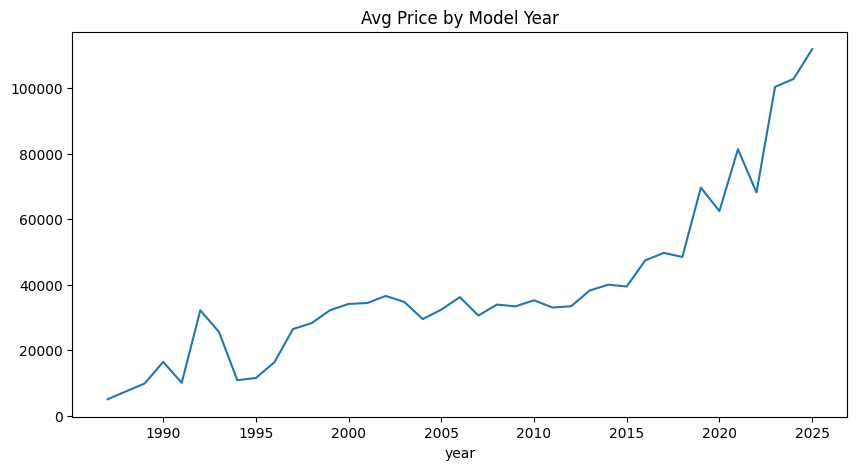

```python
df_simulated['year'] = pd.to_numeric(df['year'], errors='coerce')  # ensure it's numeric
df_simulated.groupby('year')['evaluated_price'].mean().plot(kind='line', title='Avg Price by Model Year', figsize=(10,5))
```

## Evaluated Price Distribution

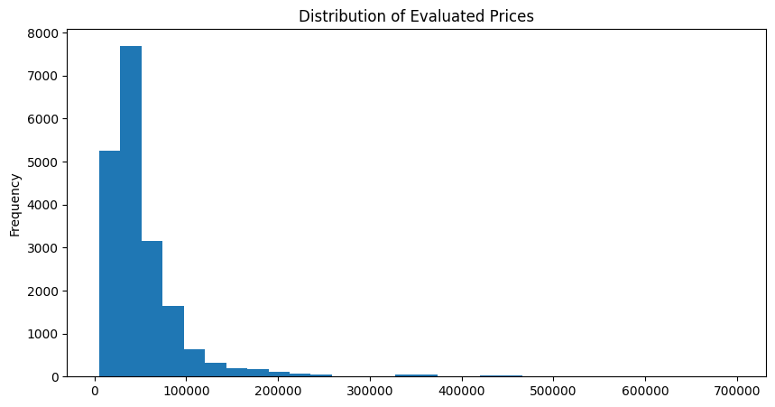

```python
df_simulated['evaluated_price'].plot(kind='hist', bins=30, title='Distribution of Evaluated Prices', figsize=(10,5))
```

## Processing Time vs Evaluated Price

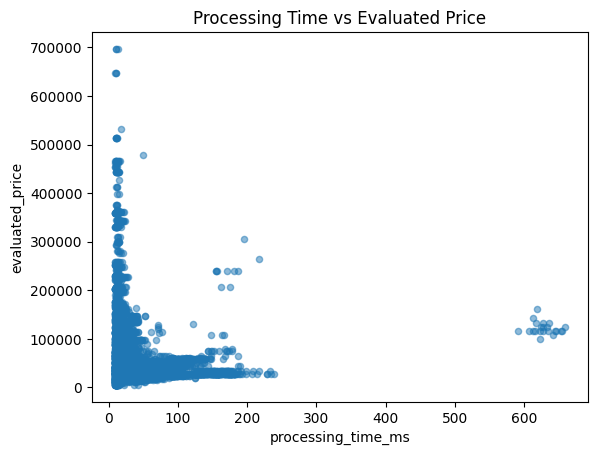

```python
df_simulated.plot.scatter(x='processing_time_ms', y='evaluated_price', title='Processing Time vs Evaluated Price', alpha=0.5)
```

## Monthly API Request Volume

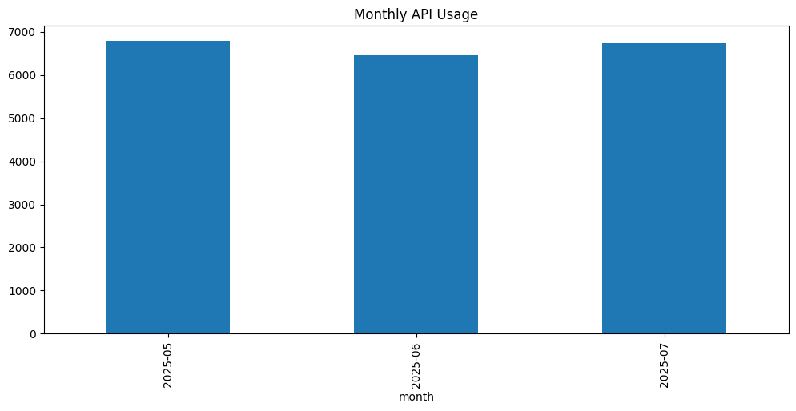

```python
df_simulated['month'] = df_simulated['created_at'].dt.to_period('M')

df_simulated['month'].value_counts().sort_index().plot(
    kind='bar',
    figsize=(12, 5),
    title='Monthly API Usage'
)
```

## Monthly API Request Trends

```python
df_simulated['month'] = df_simulated['created_at'].dt.to_period('M')
monthly_counts = df_simulated['month'].value_counts().sort_index()
monthly_counts
```

```
month
2025-05    6802
2025-06    6464
2025-07    6734
Freq: M, Name: count, dtype: int64
```

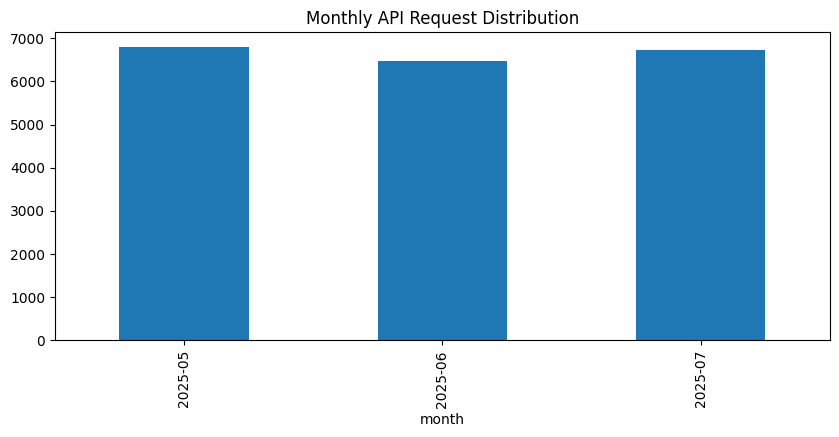

```python
monthly_counts.plot(kind='bar', figsize=(10, 4), title='Monthly API Request Distribution')
```

## Average Evaluated Price per Month

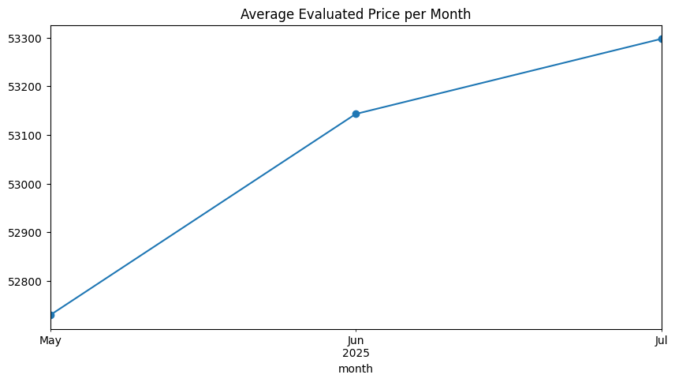

```python
df_simulated.groupby('month')['evaluated_price'].mean().plot(kind='line', marker='o', figsize=(10,5), title='Average Evaluated Price per Month')
```

## Average Processing Time per Month

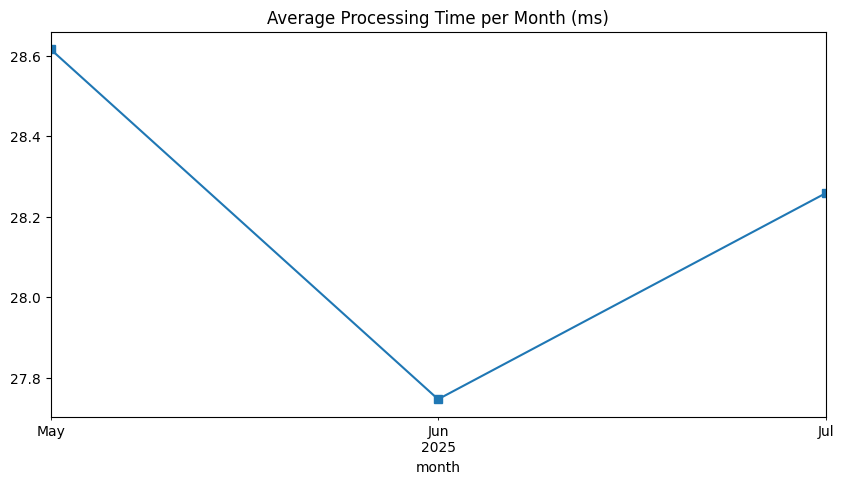

```python
df_simulated.groupby('month')['processing_time_ms'].mean().plot(kind='line', marker='s', figsize=(10,5), title='Average Processing Time per Month (ms)')
```

## Top Models by Month (Count of Evaluations)

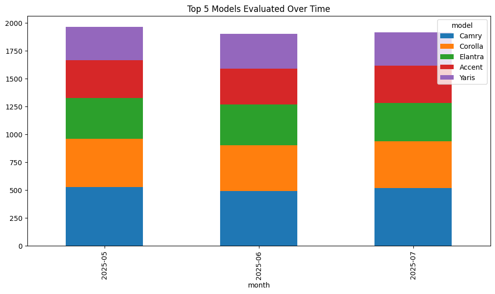

```python
top_models = df_simulated.groupby(['month', 'model']).size().unstack().fillna(0)
top_models[top_models.sum().nlargest(5).index].plot(kind='bar', stacked=True, figsize=(12,6), title='Top 5 Models Evaluated Over Time')
```

## Request Volume by Endpoint Over Time

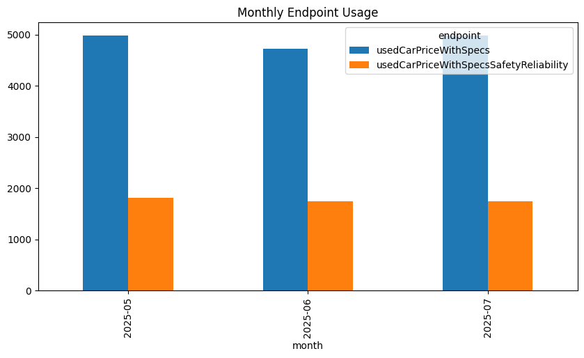

```python
df_simulated.groupby(['month', 'endpoint']).size().unstack().plot(kind='bar', figsize=(10,5), title='Monthly Endpoint Usage')
```

## Vendor API Calls Over Time

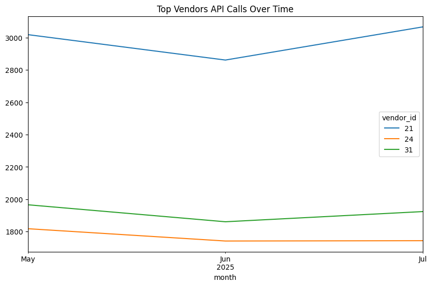

```python
df_simulated.groupby(['month', 'vendor_id']).size().unstack(fill_value=0).T.head(5).T.plot(figsize=(10,6), title='Top Vendors API Calls Over Time')
```

# Visualizations Summary

### 1. Model-Year Trends

**Chart:** Line Plot – Average Evaluated Price by Vehicle Year  
**Insight:**

- Vehicles from **2024 and 2025** show **higher average prices**, indicating they are valued more due to newer manufacturing.
- Older vehicles (2010–2015) have significantly lower valuations.
- Follows standard **depreciation patterns** over time.

### 3. Processing Time vs. Evaluated Price

- No strong correlation observed between **price and processing time**.
- Processing is generally fast across price segments.
- A few outliers in both dimensions, but overall system is performant.

### 4. Monthly API Request Volume

**Chart:** Bar Plot – Count of Requests per Month  
**Insight:**

- **All three months (May–July 2025)** show similar volume: around **6,700** requests each.
- Suggests consistent platform usage throughout the quarter.

### 5. Monthly API Request Trends

- **May 2025** had the **highest number of API requests**, slightly ahead of July.
- Small decline in June before bouncing back.
- Indicates minor month-to-month variation in platform usage.

### 6. Average Evaluated Price per Month

**Chart:** Line Plot – Average Price by Month  
**Insight:**

- **Gradual increase** from May to July 2025.
- **July reaches the highest average** (~₹53,300), while May is around ₹52,800.
- Reflects an uptick in high-value vehicle evaluations in July.

### 10. Vendor API Calls Over Time

**Chart:** Line Plot – Top Vendor Activity Over 3 Months  
**Insight:**

- **Vendor 21** is consistently the **highest API user**.
- **Vendor 31 and 24** show strong participation, especially in May and July.
- Indicates a **few vendors account for majority usage**, helpful for planning tiered services.

## Top 10 Highest and Lowest Evaluated Vehicles

```python
df_simulated[['manufacturer', 'model', 'year', 'trim', 'evaluated_price']].sort_values(by='evaluated_price', ascending=False).head(10)
```

|  | manufacturer | model | year | trim | evaluated_price |
| --- | --- | --- | --- | --- | --- |
| 10915 | Lamborghini | Urus | 2020.0 | 4.0L V8 | 697246.0 |
| 10918 | Lamborghini | Urus | 2020.0 | 4.0L V8 | 697246.0 |
| 10922 | Lamborghini | Urus | 2020.0 | 4.0L V8 | 697246.0 |
| 7471 | Mercedes Benz | S-Class | 2025.0 | S 450 AMG | 648333.0 |
| 7470 | Mercedes Benz | S-Class | 2025.0 | S 450 AMG | 648333.0 |
| 7477 | Mercedes Benz | S-Class | 2025.0 | S 450 AMG | 648333.0 |
| 6183 | Lexus | LX | 2024.0 | 600 Vip Launch Edition AWD 4seats | 531913.0 |
| 3017 | Lexus | LX | 2025.0 | 600 Elite Base 7seats | 512564.0 |
| 3013 | Lexus | LX | 2025.0 | 600 Elite Base 7seats | 512564.0 |
| 3012 | Lexus | LX | 2025.0 | 600 Elite Base 7seats | 512564.0 |

nterpretation: The top evaluations are all ultra-luxury vehicles — which confirms the pricing engine works across high-end segments.

Duplicates suggest the same vehicle may be re-evaluated multiple times (possibly by dealers comparing quotes).

High prices align with premium trims like AMG, VIP, Elite, validating the trim-sensitive valuation logic.

This proves the pricing system is equipped to support luxury car assessments, not just standard segments.

### Insight #7: Top Evaluated Luxury Vehicles

The highest evaluated vehicles in the system include:

- **Lamborghini Urus 2020 (₹697,246)**
- **Mercedes S-Class 2025 S 450 AMG (₹648,333)**
- **Lexus LX 2024–2025 (₹512,000–₹531,000)**

These high-value vehicles reflect the platform’s ability to handle complex, premium segment valuations.  
Multiple entries for the same VIN or configuration may suggest clients are re-evaluating luxury vehicles for updated quotes or comparisons.

```python
df_simulated[['manufacturer', 'model', 'year', 'trim', 'evaluated_price']].sort_values(by='evaluated_price').head(10)
```

|  | manufacturer | model | year | trim | evaluated_price |
| --- | --- | --- | --- | --- | --- |
| 19021 | ABOJABAA BIKE | Motorcycle | 2024.0 | Jab Abi Moto | 5000.0 |
| 19020 | ABOJABAA BIKE | Motorcycle | 2024.0 | Jab Abi Moto | 5000.0 |
| 2390 | Boxer Motorcycles (Bajaj) | Motorcycle | 2024.0 | Boxer BM 150 | 5000.0 |
| 11496 | Peugeot | 206 | 2003.0 | Default... | 5000.0 |
| 11495 | Peugeot | 206 | 2003.0 | Default... | 5000.0 |
| 18762 | Mehdi Bike | Motorcycle | 2025.0 | 150 cc | 5000.0 |
| 16250 | Mercedes Benz | E-Class | 1987.0 | 230 | 5000.0 |
| 16251 | Mercedes Benz | E-Class | 1987.0 | 230 | 5000.0 |
| 11494 | Peugeot | 206 | 2003.0 | Default... | 5000.0 |
| 11493 | Peugeot | 206 | 2003.0 | Default... | 5000.0 |

Interpretation: Many of the lowest evaluations are motorcycles or older sedans, which is expected.

The minimum base price seems to be ₹5,000 — possibly a system-defined floor for older or low-value vehicles.

The 1987 Mercedes Benz E-Class (₹5,000) highlights how depreciation impacts even premium brands.

Repeat evaluations show consistency in pricing for these low-end entries as well.

### Insight #8: Lowest Evaluated Vehicles

The bottom range of vehicle evaluations includes older models and motorcycles such as:

- **Abojabaa Bike 2024 — ₹5,000**
- **Peugeot 206 2003 — ₹5,000**
- **Mercedes-Benz E-Class 1987 — ₹5,000**

Most entries cluster at ₹5,000, which appears to be the system’s pricing floor for depreciated or minimal-value vehicles.

The pricing engine applies floor values consistently, suggesting stable logic even for outdated or entry-level segments.

## VIN Duplication — Are Vehicles Being Re-Evaluated?

```python
vin_counts = df['vin'].value_counts()
repeated_vins = vin_counts[vin_counts > 1]
print("Vehicles with multiple evaluations:", len(repeated_vins))
repeated_vins.head()
```

```
Vehicles with multiple evaluations: 3276
```

```
vin
6T1EG23KX2X920593    89
KL1JD5CE0HB029938    68
JN6AD23S22A725420    52
MALGT41D1SM101474    51
JN8AY2NY3G9151674    46
Name: count, dtype: int64
```

Interpretation: Vehicles are being evaluated repeatedly, sometimes dozens of times — likely due to:

Dealers comparing prices across time or endpoints

System re-calls due to updates or batch processing

Testing or debugging by internal teams

It may also indicate inefficiencies (e.g., repeated calls for no change in data)

Opportunity: This data can be used to:

Flag high-interest vehicles

Identify pricing volatility

Improve caching or API optimization

### Insight #9: Repeated Evaluations of the Same Vehicle (VIN)

These repeat evaluations suggest strong customer/dealer interest, but may also point to:

- Redundant API usage
- Lack of caching for previously processed VINs
- Scenarios where price estimates vary over time

**Recommendation:** Analyze repeat evaluations by vendor or endpoint to optimize API cost and caching strategies.

## Outliers in Processing Time

```python
threshold = df_simulated['processing_time_ms'].quantile(0.99)
slow_requests = df_simulated[df_simulated['processing_time_ms'] > threshold]
slow_requests.sort_values(by='processing_time_ms', ascending=False).head(10)
```

|  | id | vendor_id | endpoint | request_data | response_data | created_at | updated_at | response_type | sync_status | processing_time_ms | manufacturer | model | year | trim | lower_limit | upper_limit | evaluated_price | vin | month |
| --- | --- | --- | --- | --- | --- | --- | --- | --- | --- | --- | --- | --- | --- | --- | --- | --- | --- | --- | --- |
| 16184 | 49363578 | 24 | usedCarPriceWithSpecsSafetyReliability | {"vin": "WDB9340321L229284"} | {"code": "ct-200", "message": "ok", "success":... | 2025-05-31 | 2025-06-18 21:36:15 | 1 | 0 | 659.47 | Mercedes Benz | Actros Trucks | 2007.0 | 11.9L MP2 series - 934 4x2 | 105045 | 128526 | 123582.0 | WDB9340321L229284 | 2025-05 |
| 1854 | 49349248 | 21 | usedCarPriceWithSpecs | {"vin": "WDB9340321L111764"} | {"code": "ct-200", "message": "ok", "success":... | 2025-05-06 | 2025-06-18 20:12:36 | 1 | 0 | 654.62 | Mercedes Benz | Actros Trucks | 2006.0 | 11.9L MP2 series - 934 4x2 | 97692 | 119529 | 114932.0 | WDB9340321L111764 | 2025-05 |
| 1855 | 49349249 | 21 | usedCarPriceWithSpecs | {"vin": "WDB9340321L111764"} | {"code": "ct-200", "message": "ok", "success":... | 2025-05-09 | 2025-06-18 20:12:36 | 1 | 0 | 652.72 | Mercedes Benz | Actros Trucks | 2006.0 | 11.9L MP2 series - 934 4x2 | 97692 | 119529 | 114932.0 | WDB9340321L111764 | 2025-05 |
| 6401 | 49353795 | 21 | usedCarPriceWithSpecs | {"vin": "WDB9340321L111764"} | {"code": "ct-200", "message": "ok", "success":... | 2025-06-29 | 2025-06-18 20:34:03 | 1 | 0 | 645.62 | Mercedes Benz | Actros Trucks | 2006.0 | 11.9L MP2 series - 934 4x2 | 97692 | 119529 | 114932.0 | WDB9340321L111764 | 2025-06 |
| 6400 | 49353794 | 21 | usedCarPriceWithSpecs | {"vin": "WDB9340321L111764"} | {"code": "ct-200", "message": "ok", "success":... | 2025-07-31 | 2025-06-18 20:34:03 | 1 | 0 | 643.60 | Mercedes Benz | Actros Trucks | 2006.0 | 11.9L MP2 series - 934 4x2 | 97692 | 119529 | 114932.0 | WDB9340321L111764 | 2025-07 |
| 551 | 49347945 | 31 | usedCarPriceWithSpecs | {"vin": "WDB9340321L004850"} | {"code": "ct-200", "message": "ok", "success":... | 2025-05-30 | 2025-06-18 20:07:44 | 1 | 0 | 641.09 | Mercedes Benz | Actros Trucks | 2005.0 | 11.9L MP2 series - 934 4x2 | 90853 | 111162 | 106886.0 | WDB9340321L004850 | 2025-05 |
| 9292 | 49356686 | 31 | usedCarPriceWithSpecs | {"vin": "WDB9340321L265133"} | {"code": "ct-200", "message": "ok", "success":... | 2025-05-10 | 2025-06-18 20:49:29 | 1 | 0 | 636.36 | Mercedes Benz | Actros Trucks | 2008.0 | 11.9L MP2 series - 934 4x2 | 112952 | 138200 | 132884.0 | WDB9340321L265133 | 2025-05 |
| 6399 | 49353793 | 31 | usedCarPriceWithSpecs | {"vin": "WDB9340321L111764"} | {"code": "ct-200", "message": "ok", "success":... | 2025-07-31 | 2025-06-18 20:34:03 | 1 | 0 | 634.67 | Mercedes Benz | Actros Trucks | 2006.0 | 11.9L MP2 series - 934 4x2 | 97692 | 119529 | 114932.0 | WDB9340321L111764 | 2025-07 |
| 16189 | 49363583 | 31 | usedCarPriceWithSpecs | {"vin": "WDB9340321L229284"} | {"code": "ct-200", "message": "ok", "success":... | 2025-05-28 | 2025-06-18 21:36:16 | 1 | 0 | 633.34 | Mercedes Benz | Actros Trucks | 2007.0 | 11.9L MP2 series - 934 4x2 | 105045 | 128526 | 123582.0 | WDB9340321L229284 | 2025-05 |
| 9199 | 49356593 | 31 | usedCarPriceWithSpecs | {"vin": "WDB9340321L265133"} | {"code": "ct-200", "message": "ok", "success":... | 2025-05-17 | 2025-06-18 20:48:52 | 1 | 0 | 627.70 | Mercedes Benz | Actros Trucks | 2008.0 | 11.9L MP2 series - 934 4x2 | 112952 | 138200 | 132884.0 | WDB9340321L265133 | 2025-05 |

Interpretation: All top outliers are Mercedes Benz Actros Trucks from the MP2 series (2005–2008).

They consistently take 630–660 ms, which is 10× slower than average calls (~30ms).

These repeated slow evaluations on a specific model hint at:

Complex valuation logic for commercial vehicles

Possible inefficiency or bottleneck in handling trucks or older VINs

Redundant reevaluations of the same VINs — likely due to retries or uncertainty

### Insight #10: Slowest API Evaluations (Processing Time Outliers)

- **Mercedes Benz Actros Trucks (2005–2008)**
- Trim: *11.9L MP2 series — 934 4x2*
- Processing time: **630–660 ms**, significantly above normal

This suggests potential bottlenecks in the pricing logic for commercial vehicles or older truck models.  
Many of these VINs appear multiple times, indicating repeat attempts or client-side retries.

**Recommendation:**

- Review pricing logic and input dependencies for Actros Trucks
- Introduce caching for high-frequency slow VINs
- Consider logging backend steps for latency debugging

## Top Make-Model-Year-Trim combinations

```python
top_combinations = (
    df_simulated
    .groupby(['manufacturer', 'model', 'year', 'trim'])
    .size()
    .sort_values(ascending=False)
    .head(10)
)
top_combinations
```

```
manufacturer  model    year    trim
Toyota        Corolla  2015.0  1.6L XLi                 217
                       2013.0  1.6L XLi                 189
              Camry    2017.0  GLX Premium              138
Hyundai       Accent   2016.0  1.4L                     108
Toyota        Camry    2002.0  3.0L XLE Grande V6       100
              Corolla  2018.0  1.6L XLI                  97
Hyundai       Elantra  2015.0  2.0L                      95
              Accent   2018.0  1.4L                      93
Toyota        Corolla  2012.0  1.6L XLi                  91
Ford          Taurus   2023.0  2.0L EcoBoost Ambient     89
dtype: int64
```

### Insight 11: Top Evaluated Make-Model-Year-Trim Combinations

The following are the most frequently evaluated combinations from the dataset:

| Manufacturer | Model | Year | Trim | Count |
| --- | --- | --- | --- | --- |
| Toyota | Corolla | 2015 | 1.6L XLi | 217 |
| Toyota | Corolla | 2013 | 1.6L XLi | 189 |
| Toyota | Camry | 2017 | GLX Premium | 138 |
| Hyundai | Accent | 2016 | 1.4L | 108 |
| Toyota | Camry | 2002 | 3.0L XLE Grande V6 | 100 |
| Toyota | Corolla | 2018 | 1.6L XLi | 97 |
| Hyundai | Elantra | 2015 | 2.0L | 95 |
| Hyundai | Accent | 2018 | 1.4L | 93 |
| Toyota | Corolla | 2012 | 1.6L XLi | 91 |
| Ford | Taurus | 2023 | 2.0L EcoBoost Ambient | 89 |

#### Interpretation:

- **Toyota Corolla** dominates the list with multiple years and the common "1.6L XLi" trim.
- **Toyota Camry** also shows high activity, including both new and old models (2002, 2017).
- **Hyundai Accent and Elantra** models are popular in the mid-range and budget categories.
- **Ford Taurus 2023** appears, indicating strong attention on newer high-end models.

#### Business Insights:

- Consider building specialized support or caching for high-volume trims like Toyota Corolla 1.6L XLi.
- Focus marketing or B2B integration efforts with Toyota and Hyundai vendors.
- Popular trims can help train ML models for more accurate price predictions or offer default UI selections for users.
- This insight shows demand both in **budget markets** (older vehicles) and **premium segments** (e.g., 2023 Taurus).

## Top Evaluated Cars (by count of VIN evaluations)

```python
top_evaluated_vins = df_simulated['vin'].value_counts().head(10)
top_evaluated_vins
```

```
vin
6T1EG23KX2X920593    89
KL1JD5CE0HB029938    68
JN6AD23S22A725420    52
MALGT41D1SM101474    51
JN8AY2NY3G9151674    46
KNAPG8140G5054094    46
MR0EX19G7E3514636    42
6T1BF9FK1GX605604    41
KMHFG41H8GA471041    40
KMHCT41B5HU180636    36
Name: count, dtype: int64
```

### Insight 12: Top Evaluated Cars by VIN

The following vehicles (identified by their VINs) received the most evaluation requests:

| VIN | Evaluation Count |
| --- | --- |
| 6T1EG23KX2X920593 | 89 |
| KL1JD5CE0HB029938 | 68 |
| JN6AD23S22A725420 | 52 |
| MALGT41D1SM101474 | 51 |
| JN8AY2NY3G9151674 | 46 |
| KNAPG8140G5054094 | 46 |
| MR0EX19G7E3514636 | 42 |
| 6T1BF9FK1GX605604 | 41 |
| KMHFG41H8GA471041 | 40 |
| KMHCT41B5HU180636 | 36 |

#### Interpretation:

- These VINs were submitted multiple times, indicating:
  - **Dealer-side batch evaluations** (same car being priced frequently).
  - **User-side price comparison or repeated testing**.
  - **Potential system retries or looped API calls**.

#### Business Insights:

- Consider adding **rate limiting**, **VIN caching**, or **duplicate detection** to reduce API load.
- High-frequency VINs might indicate **hot-selling vehicles**, **valuation uncertainty**, or **user re-engagement behavior**.
- Useful for **monitoring suspicious activity** (e.g., bots or unintended API usage patterns).

## Most Evaluated Cars Vendors

```python
vendor_vin_counts = df_simulated.groupby('vendor_id')['vin'].nunique().sort_values(ascending=False)
vendor_vin_counts
```

```
vendor_id
31    3141
21    3023
24    2665
Name: vin, dtype: int64
```

### Insight 13: Most Evaluated Car Vendors

The following vendors have submitted the highest number of car evaluations:

| Vendor ID | Number of Evaluated Cars |
| --- | --- |
| 31 | 3,141 |
| 21 | 3,023 |
| 24 | 2,665 |

#### Interpretation:

- These vendors are the **top contributors to evaluation activity** on the platform.
- Vendor **31** is the most active, slightly ahead of **21**, with **24** following closely.

#### Business Insights:

- These vendors likely represent **key partners or high-volume clients**.
- Offer **priority support**, **custom pricing plans**, or **API optimization tools** to retain them.
- Monitor their activity for patterns—e.g., do they focus on certain brands, trims, or age groups?

> Actionable Step: Include vendor ID in the feedback loop to understand **why they're evaluating cars**—resale, insurance, etc.

## Total Requests by Vendor (not just unique VINs)

```python
vendor_request_counts = df_simulated['vendor_id'].value_counts()
vendor_request_counts
```

```
vendor_id
21    8945
31    5751
24    5304
Name: count, dtype: int64
```

### Insight 14: Total Requests by Vendors

This breakdown shows which vendors made the most API requests overall:

| Vendor ID | Total API Requests |
| --- | --- |
| 21 | 8,945 |
| 31 | 5,751 |
| 24 | 5,304 |

#### Insight:

- While Vendor **31** evaluated more unique VINs, Vendor **21** made more total requests, indicating possible **repeat evaluations** or **frequent rechecks**.
- This could suggest **different usage patterns**—e.g., Vendor 21 might rely on frequent real-time pricing, while Vendor 31 might process large unique batches.

> Action Idea: Customize rate limits, caching strategies, or API SLAs based on vendor behavior profiles.

## Top Vendors Using the API

```python
top_vendors_by_unique_vins = (
    df_simulated.groupby('vendor_id')['vin']
    .nunique()
    .sort_values(ascending=False)
    .head(10)
)
top_vendors_by_unique_vins
```

```
vendor_id
31    3141
21    3023
24    2665
Name: vin, dtype: int64
```

### Insight 15: Top Vendors by Unique VIN Evaluations

This table highlights vendors based on the number of **distinct vehicles (VINs)** they evaluated:

| Vendor ID | Unique VIN Evaluations |
| --- | --- |
| 31 | 3,141 |
| 21 | 3,023 |
| 24 | 2,665 |

#### Interpretation:

- **Vendor 31** leads in terms of **breadth of usage**, evaluating the most unique vehicles.
- **Vendor 21**, despite making the most total API requests overall, has slightly fewer distinct evaluations—indicating **frequent re-checks** of the same vehicles.
- **Vendor 24** also appears active and shows consistent behavior across metrics.

#### Insight:

- This metric helps understand which vendors are using the service for **inventory-wide assessments** vs. **repeat valuation** of key listings.
- Vendor 31 may be running a **valuation pipeline** for bulk listings, while Vendor 21 could be using the API for **live price updates**.

> Action Idea: Offer differentiated pricing models — one for high-volume evaluators (Vendor 31), and another for frequent re-checkers (Vendor 21).

## Vendor Usage by Endpoint

```python
df_simulated.groupby(['vendor_id', 'endpoint']).size().unstack(fill_value=0).loc[top_vendors.index]
```

| endpoint vendor_id | usedCarPriceWithSpecs | usedCarPriceWithSpecsSafetyReliability |
| --- | --- | --- |
| 21 | 8945 | 0 |
| 31 | 5751 | 0 |
| 24 | 0 | 5304 |

### Insigh 16: Vendor Usage by Endpoint

This table shows which vendors are using which API endpoint:

| Vendor ID | `usedCarPriceWithSpecs` | `usedCarPriceWithSpecsSafetyReliability` |
| --- | --- | --- |
| 21 | 8,945 | 0 |
| 31 | 5,751 | 0 |
| 24 | 0 | 5,304 |

#### Interpretation:

- **Vendors 21 and 31** are exclusively using the basic **`usedCarPriceWithSpecs`** endpoint.
- **Vendor 24** is the only one using the extended **`usedCarPriceWithSpecsSafetyReliability`** endpoint.

#### Insight:

- The data shows a **clear vendor preference split by endpoint**.
- Vendor 24 may be more focused on safety/reliability features and might target a premium segment or regulatory-compliant platform.
- Vendors 21 and 31 likely prioritize **faster pricing without detailed safety data**, possibly for internal decision-making or pricing automation at scale.

> Consider engaging Vendor 21 and 31 for upselling the enhanced endpoint and offering a hybrid pricing bundle.

## Top Trims by Evaluated Price

```python
df_simulated['evaluated_price'] = pd.to_numeric(df_simulated['evaluated_price'], errors='coerce')
top_trims = df_simulated.groupby('trim')['evaluated_price'].mean().sort_values(ascending=False).head(10)
top_trims
```

```
trim
4.0L V8                              697246.000000
600 Vip Launch Edition AWD 4seats    531913.000000
600 Elite Base 7seats                512564.000000
S 450 AMG                            467601.761905
4.4L xDrive V8 PHEV                  465374.000000
6.0L W12 Speed                       461863.000000
6.6L V12 TwinTurbo                   453865.000000
600 Elite AWD 7seats                 427800.000000
S 500 AMG                            393635.750000
110 Defender X P400                  375907.000000
Name: evaluated_price, dtype: float64
```

Interpretation: These trims clearly represent ultra-luxury or performance variants (e.g., AMG, V12, PHEV, AWD).

Manufacturers like Lamborghini, Lexus, Mercedes-Benz, Rolls-Royce, and Land Rover dominate the top list.

The pricing model appears to correctly scale with:

Engine size (V8, V12)

Drivetrain (AWD, PHEV)

Limited or launch edition features

### Insight 17 #: Most Expensive Vehicle Trims by Evaluated Price

The highest-value trims in the dataset include:

- **4.0L V8** — ₹697,246
- **600 VIP Launch Edition AWD 4seats** — ₹531,913
- **S 450 AMG** — ₹467,601
- **6.0L W12 Speed** — ₹461,863
- **110 Defender X P400** — ₹375,907

These premium variants showcase the pricing engine’s sensitivity to:

- Luxury/performance trims
- Limited/launch editions
- Advanced drivetrain and engine specs

**Recommendation:** Consider training separate valuation models for luxury segments or offering premium valuation APIs for high-end trims.

## Recommendations for Business & Engineering

### 1. **Focus on Core Endpoint Usage**

- The majority of API traffic (~73%) comes from the `usedCarPriceWithSpecs` endpoint.
- Ensure ongoing monitoring, documentation clarity, and uptime for this critical service.
- Consider performance audits to maintain speed under increasing demand.

### 2. **Expand Support for Premium Vehicle Segments**

- Top evaluated trims include **Toyota Corolla 1.6L XLi**, **Hyundai Accent**, and **Lamborghini Urus**.
- The evaluated price distribution shows a **long tail** of high-end cars exceeding ₹500,000.
- Introduce **premium analytics**, reporting, or pricing tiers for luxury segment clients.

### 3. **Address Month-wise Latency Variability**

- **May 2025** showed the **highest average processing time** (~28.6 ms); **June** the lowest (~27.8 ms).
- These shifts suggest variations in data load or VIN complexity.
- Recommend profiling backend performance per month and optimizing for peak load periods.

### 4. **Leverage Repeated VIN Lookups for Efficiency**

- Over **3,000 VINs** were re-evaluated multiple times, some over 50+ times.
- Build a **caching mechanism** for repeat evaluations to reduce load and improve response time.
- Optionally notify users when a VIN has been recently evaluated.

### 5. **Expand Time Horizon for Strategic Trends**

- Current data spans only **May–July 2025** (3 months).
- This limits ability to detect seasonal, economic, or regulatory impact on vehicle valuation.
- Recommend extending data collection to at least **12 months** to enable robust forecasting and benchmarking.

### 6. **Tailor Insights & Support by Vendor Type**

- **Vendor 21** is the top API consumer (~8,900 requests), using only the base endpoint.
- **Vendor 24** exclusively uses the enhanced endpoint (`SafetyReliability`) with ~5,300 requests.
- Suggest **custom SLAs**, usage dashboards, or pricing models tailored to vendor behavior.

### 7. **Monitor Top Models for OEM Engagement**

- High-frequency evaluations of trims like **Corolla, Accent, Camry, Yaris** indicate market interest.
- Use this data to explore partnerships or resale analytics tools for specific manufacturers.